# PA1_template

Yan

Saturday, September 19, 2015

# Loading and preprocessing the data

Loading data

```r
aData <- read.csv("activity.csv",sep = ",", colClasses = c("integer", "Date", "factor"))
head(aData)
```

```
##   steps       date interval
## 1    NA 2012-10-01        0
## 2    NA 2012-10-01        5
## 3    NA 2012-10-01       10
## 4    NA 2012-10-01       15
## 5    NA 2012-10-01       20
## 6    NA 2012-10-01       25
```

Process/transform the data

```r
aData$month<- as.numeric(format(aData$date, "%m"))
head(aData)
```

```
##   steps       date interval month
## 1    NA 2012-10-01        0    10
## 2    NA 2012-10-01        5    10
## 3    NA 2012-10-01       10    10
## 4    NA 2012-10-01       15    10
## 5    NA 2012-10-01       20    10
## 6    NA 2012-10-01       25    10
```

```r
noNA.Data <- na.omit(aData)
rownames(noNA.Data) <- 1:nrow(noNA.Data)
head(noNA.Data)
```

```
##   steps       date interval month
## 1     0 2012-10-02        0    10
## 2     0 2012-10-02        5    10
## 3     0 2012-10-02       10    10
## 4     0 2012-10-02       15    10
## 5     0 2012-10-02       20    10
## 6     0 2012-10-02       25    10
```

# What is mean total number of steps taken per day?

## Calculate the total number of steps taken per day

Make a histogram of the total number of steps taken each day

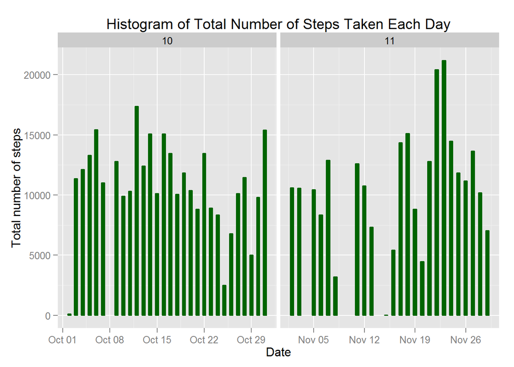

```r
library(ggplot2)
ggplot(noNA.Data, aes(date, steps)) + geom_bar(stat = "identity", colour = "darkgreen", fill = "darkgreen", width = 0.5) + facet_grid(. ~ month, scales = "free") + labs(title = "Histogram of Total Number of Steps Taken Each Day", x = "Date", y = "Total number of steps")
```

## Calculate and report the mean and median total number of steps taken per day

Mean total number of steps taken per day:

```r
totalSteps <- aggregate(noNA.Data$steps, list(Date = noNA.Data$date), FUN = "sum")$x
mean(totalSteps)
```

```
## [1] 10766.19
```

Median total number of steps taken per day:

```r
median(totalSteps)
```

```
## [1] 10765
```

# What is the average daily activity pattern?

Make a time series plot (i.e. type = “1”) of the 5-minute interval (x-axis) and the average number of steps taken, averaged across all days (y-axis)

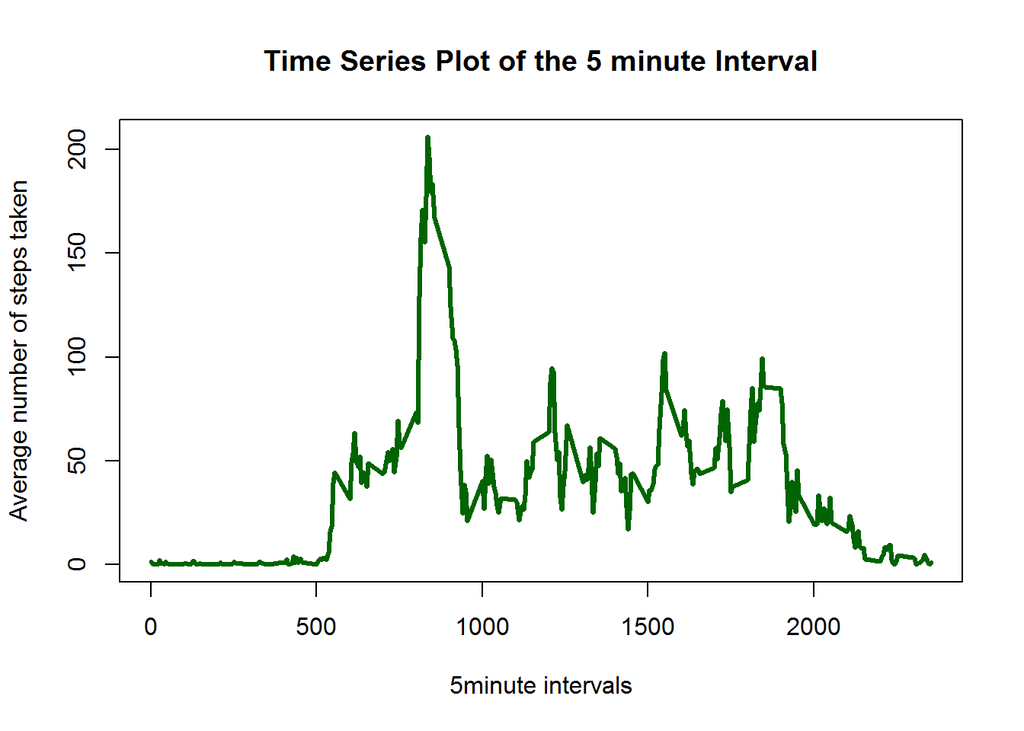

```r
avgSteps <- aggregate(noNA.Data$steps, list(interval = as.numeric(as.character(noNA.Data$interval))), FUN = "mean")
names(avgSteps)[2] <- "meanSteps"

plot(avgSteps$interval, avgSteps$meanSteps, type="l",main = "Time Series Plot of the 5 minute Interval", xlab = "5minute intervals", ylab = "Average number of steps taken", ,col="darkgreen", lwd = 3 )
```

Which 5-minute interval, on average across all the days in the dataset, contains the maximum number of steps?

```r
avgSteps[avgSteps$meanSteps == max(avgSteps$meanSteps), ]
```

```
##     interval meanSteps
## 104      835  206.1698
```

# Imputing missing values

Calculate and report the total number of missing values in the dataset (i.e. the total number of rows with NAs)

```r
sum(is.na(aData))
```

```
## [1] 2304
```

All of the missing values are filled in with mean value for that 5-minute interval

```r
newData <- aData
for (i in 1:nrow(newData)) {
    if (is.na(newData$steps[i])) {
        newData$steps[i] <- avgSteps[which(newData$interval[i] == avgSteps$interval), ]$meanSteps
    }
}

head(newData)
```

```
##       steps       date interval month
## 1 1.7169811 2012-10-01        0    10
## 2 0.3396226 2012-10-01        5    10
## 3 0.1320755 2012-10-01       10    10
## 4 0.1509434 2012-10-01       15    10
## 5 0.0754717 2012-10-01       20    10
## 6 2.0943396 2012-10-01       25    10
```

```r
sum(is.na(newData))
```

```
## [1] 0
```

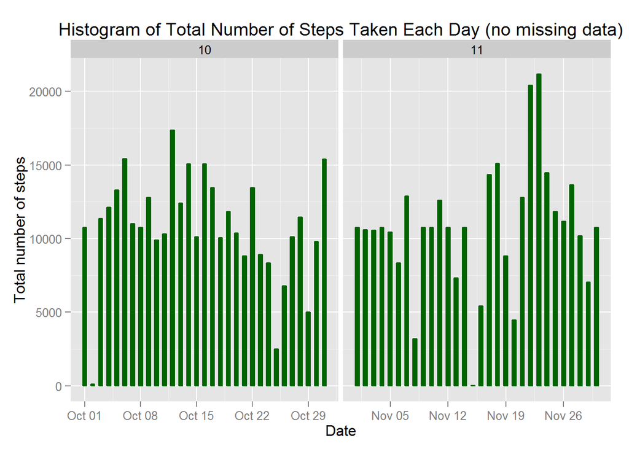

```r
ggplot(newData, aes(date, steps)) + geom_bar(stat = "identity",
                                             colour = "darkgreen",
                                             fill = "darkgreen",
                                             width = 0.5) + facet_grid(. ~ month, scales = "free") + labs(title = "Histogram of Total Number of Steps Taken Each Day (no missing data)", x = "Date", y = "Total number of steps")
```

# Are there differences in activity patterns between weekdays and weekends?

Create a new factor variable in the dataset with two levels - “weekday” and “weekend” indicating whether a given date is a weekday or weekend day

```r
newData <- aData
head(newData)
```

```
##   steps       date interval month
## 1    NA 2012-10-01        0    10
## 2    NA 2012-10-01        5    10
## 3    NA 2012-10-01       10    10
## 4    NA 2012-10-01       15    10
## 5    NA 2012-10-01       20    10
## 6    NA 2012-10-01       25    10
```

```r
newData$weekdays <- factor(format(newData$date, "%A"))
levels(newData$weekdays)
```

```
## [1] "Friday"    "Monday"    "Saturday"  "Sunday"    "Thursday"  "Tuesday"
## [7] "Wednesday"
```

```r
head(newData)
```

```
##   steps       date interval month weekdays
## 1    NA 2012-10-01        0    10   Monday
## 2    NA 2012-10-01        5    10   Monday
## 3    NA 2012-10-01       10    10   Monday
## 4    NA 2012-10-01       15    10   Monday
## 5    NA 2012-10-01       20    10   Monday
## 6    NA 2012-10-01       25    10   Monday
```

```r
levels(newData$weekdays) <- list(weekday = c("Monday", "Tuesday",
                                             "Wednesday",
                                             "Thursday", "Friday"),
                                 weekend = c("Saturday", "Sunday"))
head(newData)
```

```
##   steps       date interval month weekdays
## 1    NA 2012-10-01        0    10  weekday
## 2    NA 2012-10-01        5    10  weekday
## 3    NA 2012-10-01       10    10  weekday
## 4    NA 2012-10-01       15    10  weekday
## 5    NA 2012-10-01       20    10  weekday
## 6    NA 2012-10-01       25    10  weekday
```

```r
levels(newData$weekdays)
```

```
## [1] "weekday" "weekend"
```

Make a panel plot containing a time series plot (i.e. type = “l”) of the 5-minute interval (x-axis) and the average number of steps taken, averaged across all weekday days or weekend days (y-axis)

[figure not shown]

```r
avgSteps <- aggregate(steps ~ interval + weekdays, newData, mean)

names(avgSteps)[3] <- "meanSteps"
library(lattice)
xyplot(avgSteps$meanSteps ~ avgSteps$interval | avgSteps$weekdays,
       layout = c(1, 2), type = "l",
       xlab = "Interval", ylab = "Number of steps")
```